# Laboratorio 3: Técnicas de Reducción de la Dimensionalidad

### Ejercicio 2.4: ¿Cuántas componentes retener?

```r
# Criterio 1: Varianza acumulada > 90%
var_cumsum <- cumsum(pca_result$sdev^2 / sum(pca_result$sdev^2))
n_comp_90 <- which(var_cumsum >= 0.90)[1]
cat("Componentes necesarias para 90% varianza:", n_comp_90, "\n")
```

```
Componentes necesarias para 90% varianza: 2
```

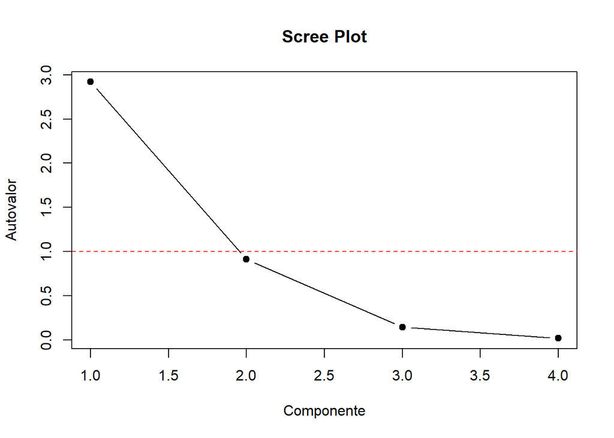

```r
# Criterio 2: Scree plot (criterio del codo)
# Buscar el "codo" en el gráfico
plot(pca_result$sdev^2, type = "b", pch = 19,
     xlab = "Componente", ylab = "Autovalor",
     main = "Scree Plot")
abline(h = 1, col = "red", lty = 2)
```

```r
# Criterio 3: Kaiser (autovalor > 1, solo si datos estandarizados)
n_comp_kaiser <- sum(pca_result$sdev^2 > 1)
cat("Componentes según criterio de Kaiser (λ > 1):", n_comp_kaiser, "\n")
```

```
Componentes según criterio de Kaiser (λ > 1): 1
```

# Parte 3: Escalado Multidimensional (MDS)

**Objetivo**: Visualizar similitudes/distancias entre observaciones.

### Ejercicio 3.1: MDS con distancias euclídeas

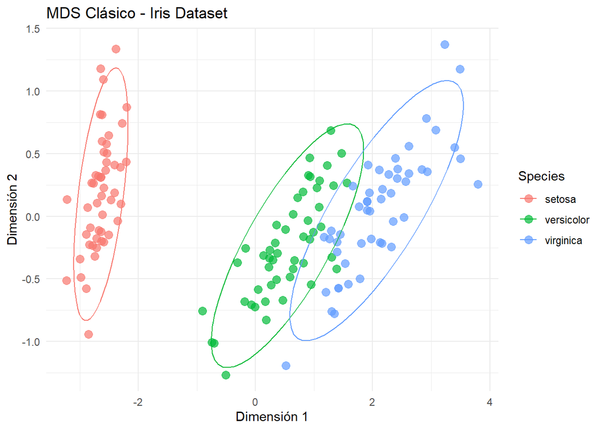

```r
# Calcular matriz de distancias
dist_matrix <- dist(iris[, 1:4])

# MDS clásico (métrico)
mds_result <- cmdscale(dist_matrix, k = 2, eig = TRUE)

# Coordenadas MDS
mds_coords <- as.data.frame(mds_result$points)
colnames(mds_coords) <- c("Dim1", "Dim2")
mds_coords$Species <- iris$Species

# Visualizar
ggplot(mds_coords, aes(x = Dim1, y = Dim2, color = Species)) +
  geom_point(size = 3, alpha = 0.7) +
  stat_ellipse() +
  labs(title = "MDS Clásico - Iris Dataset",
       x = "Dimensión 1", y = "Dimensión 2") +
  theme_minimal()
```

```r
# Bondad de ajuste
cat("Bondad de ajuste (GOF):",
    round(mds_result$GOF[1], 4), "\n")
```

```
Bondad de ajuste (GOF): 0.9777
```

### Ejercicio 3.2: Comparación PCA vs MDS

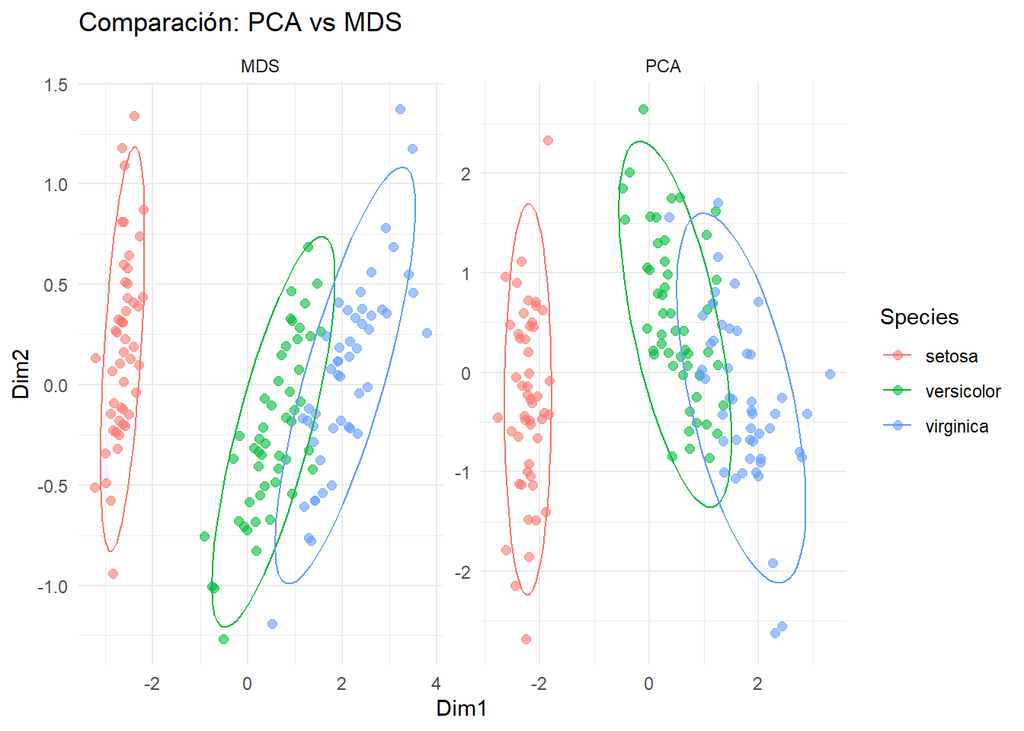

```r
# PCA
pca_iris <- prcomp(iris[, 1:4], scale. = TRUE)
pca_coords <- as.data.frame(pca_iris$x[, 1:2])
pca_coords$Species <- iris$Species
pca_coords$Method <- "PCA"
colnames(pca_coords)[1:2] <- c("Dim1", "Dim2")

# MDS
mds_coords$Method <- "MDS"

# Combinar
combined <- rbind(pca_coords, mds_coords)

# Visualizar ambos
ggplot(combined, aes(x = Dim1, y = Dim2, color = Species)) +
  geom_point(size = 2, alpha = 0.6) +
  facet_wrap(~Method, scales = "free") +
  stat_ellipse() +
  labs(title = "Comparación: PCA vs MDS") +
  theme_minimal()
```

**Pregunta**: ¿Qué diferencias observas entre PCA y MDS?

# Recursos Adicionales

## Librerías útiles en R

- `caret`: selección de variables y ML
- `FactoMineR`: PCA, MDS
- `factoextra`: visualización de análisis multivariantes
- `corrplot`: matrices de correlación
- `MASS`: funciones estadísticas avanzadas

## Lecturas recomendadas

1. Peña, D. (2013). *Análisis de datos multivariantes*. McGraw-Hill España.
2. James et al. (2013). *An Introduction to Statistical Learning*.
3. Hastie et al. (2009). *The Elements of Statistical Learning*.

## Datasets para practicar

- UCI ML Repository: https://archive.ics.uci.edu/ml/
- Kaggle Datasets: https://www.kaggle.com/datasets
- R datasets: `data()` para ver todos los disponibles

**Fin del Laboratorio 3**